# Biostat 203B Homework 1

Due Jan 26, 2024 @ 11:59PM

Author

Yuxin Zhang UID:406328706

## Q1. Git/GitHub

**No handwritten homework reports are accepted for this course.** We work with Git and GitHub. Efficient and abundant use of Git, e.g., frequent and well-documented commits, is an important criterion for grading your homework.

1. Apply for the [Student Developer Pack](https://education.github.com/pack) at GitHub using your UCLA email. You’ll get GitHub Pro account for free (unlimited public and private repositories).
2. Create a **private** repository `biostat-203b-2024-winter` and add `Hua-Zhou` and TA team (`Tomoki-Okuno` for Lec 1; `jonathanhori` and `jasenzhang1` for Lec 80) as your collaborators with write permission.
3. Top directories of the repository should be `hw1`, `hw2`, … Maintain two branches `main` and `develop`. The `develop` branch will be your main playground, the place where you develop solution (code) to homework problems and write up report. The `main` branch will be your presentation area. Submit your homework files (Quarto file `qmd`, `html` file converted by Quarto, all code and extra data sets to reproduce results) in the `main` branch.
4. After each homework due date, course reader and instructor will check out your `main` branch for grading. Tag each of your homework submissions with tag names `hw1`, `hw2`, … Tagging time will be used as your submission time. That means if you tag your `hw1` submission after deadline, penalty points will be deducted for late submission.
5. After this course, you can make this repository public and use it to demonstrate your skill sets on job market.

**Answer:** Display the URL of my GiHub repository [here](https://github.com/yuxinjoyce/biostat-203b-2024-winter).

## Q2. Data ethics training

This exercise (and later in this course) uses the [MIMIC-IV data v2.2](https://physionet.org/content/mimiciv/2.2/), a freely accessible critical care database developed by the MIT Lab for Computational Physiology. Follow the instructions at https://mimic.mit.edu/docs/gettingstarted/ to (1) complete the CITI `Data or Specimens Only Research` course and (2) obtain the PhysioNet credential for using the MIMIC-IV data. Display the verification links to your completion report and completion certificate here. **You must complete Q2 before working on the remaining questions.** (Hint: The CITI training takes a few hours and the PhysioNet credentialing takes a couple days; do not leave it to the last minute.)

**Answer:** Here is the link to my [completion report](https://www.citiprogram.org/verify/?k9b30ee2d-cb9b-4395-8e6e-fa681a7f95f1-60370426).

Here is the link to my [completion certificate](https://www.citiprogram.org/verify/?w75b8ecb6-c2fe-438e-9f74-c191fbb2095a-60370426).

## Q3. Linux Shell Commands

1. Make the MIMIC v2.2 data available at location `~/mimic`.

```bash
ls -l ~/mimic/
```

Refer to the documentation https://physionet.org/content/mimiciv/2.2/ for details of data files. Please, do **not** put these data files into Git; they are big. Do **not** copy them into your directory. Do **not** decompress the gz data files. These create unnecessary big files and are not big-data-friendly practices. Read from the data folder `~/mimic` directly in following exercises.

Use Bash commands to answer following questions.

**Answer:** I created a symbolic link ‘mimic’ to my MIMIC data folder. Here is the output of `ls -l ~/mimic/`:

```bash
ls -l ~/mimic/
```

```
total 48
-rw-rw-r--@  1 yuxin  staff  13332 Jan  5  2023 CHANGELOG.txt
-rw-rw-r--@  1 yuxin  staff   2518 Jan  5  2023 LICENSE.txt
-rw-rw-r--@  1 yuxin  staff   2884 Jan  6  2023 SHA256SUMS.txt
drwxr-xr-x@ 25 yuxin  staff    800 Jan 24 23:24 hosp
drwxr-xr-x@ 11 yuxin  staff    352 Jan  5 11:52 icu
```

2. Display the contents in the folders `hosp` and `icu` using Bash command `ls -l`. Why are these data files distributed as `.csv.gz` files instead of `.csv` (comma separated values) files? Read the page https://mimic.mit.edu/docs/iv/ to understand what’s in each folder.

```bash
ls -l ~/mimic/hosp ~/mimic/icu
```

```
/Users/yuxin/mimic/hosp:
total 8859752
-rw-rw-r--@ 1 yuxin  staff    15516088 Jan  5  2023 admissions.csv.gz
-rw-rw-r--@ 1 yuxin  staff      427468 Jan  5  2023 d_hcpcs.csv.gz
-rw-rw-r--@ 1 yuxin  staff      859438 Jan  5  2023 d_icd_diagnoses.csv.gz
-rw-rw-r--@ 1 yuxin  staff      578517 Jan  5  2023 d_icd_procedures.csv.gz
-rw-rw-r--@ 1 yuxin  staff       12900 Jan  5  2023 d_labitems.csv.gz
-rw-rw-r--@ 1 yuxin  staff    25070720 Jan  5  2023 diagnoses_icd.csv.gz
-rw-rw-r--@ 1 yuxin  staff     7426955 Jan  5  2023 drgcodes.csv.gz
-rw-rw-r--@ 1 yuxin  staff   508524623 Jan  5  2023 emar.csv.gz
-rw-rw-r--@ 1 yuxin  staff   471096030 Jan  5  2023 emar_detail.csv.gz
-rw-rw-r--@ 1 yuxin  staff     1767138 Jan  5  2023 hcpcsevents.csv.gz
-rw-rw-r--@ 1 yuxin  staff  1939088924 Jan  5  2023 labevents.csv.gz
-rw-rw-r--@ 1 yuxin  staff    96698496 Jan  5  2023 microbiologyevents.csv.gz
-rw-rw-r--@ 1 yuxin  staff    36124944 Jan  5  2023 omr.csv.gz
-rw-rw-r--@ 1 yuxin  staff     2312631 Jan  5  2023 patients.csv.gz
-rw-rw-r--@ 1 yuxin  staff   398753125 Jan  5  2023 pharmacy.csv.gz
-rw-rw-r--@ 1 yuxin  staff   498505135 Jan  5  2023 poe.csv.gz
-rw-rw-r--@ 1 yuxin  staff    25477219 Jan  5  2023 poe_detail.csv.gz
-rw-rw-r--@ 1 yuxin  staff   458817415 Jan  5  2023 prescriptions.csv.gz
-rw-rw-r--@ 1 yuxin  staff     6027067 Jan  5  2023 procedures_icd.csv.gz
-rw-rw-r--@ 1 yuxin  staff      122507 Jan  5  2023 provider.csv.gz
-rw-rw-r--@ 1 yuxin  staff     6781247 Jan  5  2023 services.csv.gz
-rw-rw-r--@ 1 yuxin  staff    36158338 Jan  5  2023 transfers.csv.gz

/Users/yuxin/mimic/icu:
total 6155968
-rw-rw-r--@ 1 yuxin  staff       35893 Jan  5  2023 caregiver.csv.gz
-rw-rw-r--@ 1 yuxin  staff  2467761053 Jan  5  2023 chartevents.csv.gz
-rw-rw-r--@ 1 yuxin  staff       57476 Jan  5  2023 d_items.csv.gz
-rw-rw-r--@ 1 yuxin  staff    45721062 Jan  5  2023 datetimeevents.csv.gz
-rw-rw-r--@ 1 yuxin  staff     2614571 Jan  5  2023 icustays.csv.gz
-rw-rw-r--@ 1 yuxin  staff   251962313 Jan  5  2023 ingredientevents.csv.gz
-rw-rw-r--@ 1 yuxin  staff   324218488 Jan  5  2023 inputevents.csv.gz
-rw-rw-r--@ 1 yuxin  staff    38747895 Jan  5  2023 outputevents.csv.gz
-rw-rw-r--@ 1 yuxin  staff    20717852 Jan  5  2023 procedureevents.csv.gz
```

**Answer:** The “.gz” extension indicates that the files are compressed using gzip, a file compression utility.

3. Briefly describe what Bash commands `zcat`, `zless`, `zmore`, and `zgrep` do.

**Answer:** `zcat`: view files without decompressing them. `zless`:view the content of compressed files one screen at a time `zmore`: page through the content of compressed files `zgrep`:search the contents of a compressed file without uncompressing it

4. (Looping in Bash) What’s the output of the following bash script?

```bash
for datafile in ~/mimic/hosp/{a,l,pa}*.gz
do
  ls -l $datafile
done
```

Display the number of lines in each data file using a similar loop. (Hint: combine linux commands `zcat <` and `wc -l`.)

```bash
for datafile in ~/mimic/hosp/{a,l,pa}*.gz
do
  echo "Number of lines in $datafile:"
  zcat < $datafile | wc -l
done
```

```
Number of lines in /Users/yuxin/mimic/hosp/admissions.csv.gz:
  431232
Number of lines in /Users/yuxin/mimic/hosp/labevents.csv.gz:
 118171368
Number of lines in /Users/yuxin/mimic/hosp/patients.csv.gz:
  299713
```

5. Display the first few lines of `admissions.csv.gz`. How many rows are in this data file? How many unique patients (identified by `subject_id`) are in this data file? Do they match the number of patients listed in the `patients.csv.gz` file? (Hint: combine Linux commands `zcat <`, `head`/`tail`, `awk`, `sort`, `uniq`, `wc`, and so on.)

```bash
zcat <  ~/mimic/hosp/admissions.csv.gz | head
```

```
subject_id,hadm_id,admittime,dischtime,deathtime,admission_type,admit_provider_id,admission_location,discharge_location,insurance,language,marital_status,race,edregtime,edouttime,hospital_expire_flag
10000032,22595853,2180-05-06 22:23:00,2180-05-07 17:15:00,,URGENT,P874LG,TRANSFER FROM HOSPITAL,HOME,Other,ENGLISH,WIDOWED,WHITE,2180-05-06 19:17:00,2180-05-06 23:30:00,0
10000032,22841357,2180-06-26 18:27:00,2180-06-27 18:49:00,,EW EMER.,P09Q6Y,EMERGENCY ROOM,HOME,Medicaid,ENGLISH,WIDOWED,WHITE,2180-06-26 15:54:00,2180-06-26 21:31:00,0
10000032,25742920,2180-08-05 23:44:00,2180-08-07 17:50:00,,EW EMER.,P60CC5,EMERGENCY ROOM,HOSPICE,Medicaid,ENGLISH,WIDOWED,WHITE,2180-08-05 20:58:00,2180-08-06 01:44:00,0
10000032,29079034,2180-07-23 12:35:00,2180-07-25 17:55:00,,EW EMER.,P30KEH,EMERGENCY ROOM,HOME,Medicaid,ENGLISH,WIDOWED,WHITE,2180-07-23 05:54:00,2180-07-23 14:00:00,0
10000068,25022803,2160-03-03 23:16:00,2160-03-04 06:26:00,,EU OBSERVATION,P51VDL,EMERGENCY ROOM,,Other,ENGLISH,SINGLE,WHITE,2160-03-03 21:55:00,2160-03-04 06:26:00,0
10000084,23052089,2160-11-21 01:56:00,2160-11-25 14:52:00,,EW EMER.,P6957U,WALK-IN/SELF REFERRAL,HOME HEALTH CARE,Medicare,ENGLISH,MARRIED,WHITE,2160-11-20 20:36:00,2160-11-21 03:20:00,0
10000084,29888819,2160-12-28 05:11:00,2160-12-28 16:07:00,,EU OBSERVATION,P63AD6,PHYSICIAN REFERRAL,,Medicare,ENGLISH,MARRIED,WHITE,2160-12-27 18:32:00,2160-12-28 16:07:00,0
10000108,27250926,2163-09-27 23:17:00,2163-09-28 09:04:00,,EU OBSERVATION,P38XXV,EMERGENCY ROOM,,Other,ENGLISH,SINGLE,WHITE,2163-09-27 16:18:00,2163-09-28 09:04:00,0
10000117,22927623,2181-11-15 02:05:00,2181-11-15 14:52:00,,EU OBSERVATION,P2358X,EMERGENCY ROOM,,Other,ENGLISH,DIVORCED,WHITE,2181-11-14 21:51:00,2181-11-15 09:57:00,0
```

```bash
zcat < ~/mimic/hosp/admissions.csv.gz | wc -l
```

```
  431232
```

```bash
zcat < ~/mimic/hosp/admissions.csv.gz | awk -F',' 'NR>1 {print $1}' | sort -u | wc -l
```

```
  180733
```

```bash
zcat < ~/mimic/hosp/patients.csv.gz | tail -n +2 | cut -d',' -f1 | uniq | wc -l
```

```
  299712
```

6. What are the possible values taken by each of the variable `admission_type`, `admission_location`, `insurance`, and `ethnicity`? Also report the count for each unique value of these variables. (Hint: combine Linux commands `zcat`, `head`/`tail`, `awk`, `uniq -c`, `wc`, and so on; skip the header line.)

```bash
zcat  < ~/mimic/hosp/admissions.csv.gz | tail -n +2 | awk -F ',' '{print $6}' | sort | uniq -c
zcat  < ~/mimic/hosp/admissions.csv.gz | tail -n +2 | awk -F ',' '{print $8}' | sort | uniq -c
zcat  < ~/mimic/hosp/admissions.csv.gz | tail -n +2 | awk -F ',' '{print $10}' | sort | uniq -c
zcat  < ~/mimic/hosp/admissions.csv.gz | tail -n +2 | awk -F ',' '{print $13}' | sort | uniq -c
```

```
6626 AMBULATORY OBSERVATION
19554 DIRECT EMER.
18707 DIRECT OBSERVATION
10565 ELECTIVE
94776 EU OBSERVATION
149413 EW EMER.
52668 OBSERVATION ADMIT
34231 SURGICAL SAME DAY ADMISSION
44691 URGENT
 185 AMBULATORY SURGERY TRANSFER
10008 CLINIC REFERRAL
232595 EMERGENCY ROOM
 359 INFORMATION NOT AVAILABLE
4205 INTERNAL TRANSFER TO OR FROM PSYCH
5479 PACU
```

[output cut: 41 more lines]

7. *To compress, or not to compress. That’s the question.* Let’s focus on the big data file `labevents.csv.gz`. Compare compressed gz file size to the uncompressed file size. Compare the run times of `zcat < ~/mimic/labevents.csv.gz | wc -l` versus `wc -l labevents.csv`. Discuss the trade off between storage and speed for big data files. (Hint: `gzip -dk < FILENAME.gz > ./FILENAME`. Remember to delete the large `labevents.csv` file after the exercise.)

```bash
du -h ~/mimic/hosp/labevents.csv.gz
```

```
1.8G    /Users/yuxin/mimic/hosp/labevents.csv.gz
```

```bash
gzip -dk < ~/mimic/hosp/labevents.csv.gz > ./labevents.csv
du -h ./labevents.csv
```

```
 13G    ./labevents.csv
```

```bash
time zcat < ~/mimic/hosp/labevents.csv.gz | wc -l
```

```
 118171368

real    0m18.738s
user    0m22.861s
sys 0m1.964s
```

```bash
time wc -l ./labevents.csv
```

```
 118171368 ./labevents.csv

real    0m5.864s
user    0m4.272s
sys 0m1.387s
```

```bash
rm ./labevents.csv
```

## Q4. Who’s popular in Price and Prejudice

1. You and your friend just have finished reading *Pride and Prejudice* by Jane Austen. Among the four main characters in the book, Elizabeth, Jane, Lydia, and Darcy, your friend thinks that Darcy was the most mentioned. You, however, are certain it was Elizabeth. Obtain the full text of the novel from http://www.gutenberg.org/cache/epub/42671/pg42671.txt and save to your local folder.

```bash
wget -nc http://www.gutenberg.org/cache/epub/42671/pg42671.txt
```

Explain what `wget -nc` does. Do **not** put this text file `pg42671.txt` in Git. Complete the following loop to tabulate the number of times each of the four characters is mentioned using Linux commands.

```bash
wget -nc http://www.gutenberg.org/cache/epub/42671/pg42671.txt
for char in Elizabeth Jane Lydia Darcy
do
  echo $char:
  # some bash commands here
done
```

```bash
wget -nc http://www.gutenberg.org/cache/epub/42671/pg42671.txt
for char in Elizabeth Jane Lydia Darcy
do
  echo $char:
  grep -o -i "$char" pg42671.txt | wc -l
done
```

[output not shown]

**Answer:** Elizabeth:634 Jane:293 Lydia:171 Darcy:418.

The wget command is a utility for downloading files from the web using the command line. The -nc option in the context of wget stands for “no-clobber,” and its primary purpose is to prevent overwriting existing files. In this question, `wget -nc` download the Price and Prejudice from http://www.gutenberg.org/cache/epub/42671/pg42671.txt if it does not exist locally or if it differs in size from the remote version.

2. What’s the difference between the following two commands?

```bash
echo 'hello, world' > test1.txt
```

```bash
echo 'hello, world' >> test2.txt
```

**Answer:** The difference between the two commands is that the first command will overwrite the file with the new text if it already exists, while the second command will add the new text to the end of the file without overwriting existing contentif it already exists.

3. Using your favorite text editor (e.g., `vi`), type the following and save the file as `middle.sh`:

```bash
#!/bin/sh
# Select lines from the middle of a file.
# Usage: bash middle.sh filename end_line num_lines
head -n "$2" "$1" | tail -n "$3"
```

Using `chmod` to make the file executable by the owner, and run

```bash
./middle.sh pg42671.txt 20 5
```

Explain the output. Explain the meaning of `"$1"`, `"$2"`, and `"$3"` in this shell script. Why do we need the first line of the shell script?

```bash
vi middle.sh
```

```bash
chmod +x middle.sh
```

```bash
./middle.sh pg42671.txt 20 5
```

```
Editor: R. W. Chapman

Release date: May 9, 2013 [eBook #42671]

Language: English
```

**Answer:** The output is 16-20 lines of the file pg42671.txt. `"$1"` is the pg42671.txt, which is the filename. `"$2"` is 20, which is the end_line. `"$3"` is 5, which is the num_lines. The first line is the shebang and specifies the interpreter to use. Without it, the script might be interpreted by a different shell, and the behavior could be different.

```bash
rm ./pg42671.txt
```

## Q5. More fun with Linux

Try following commands in Bash and interpret the results: `cal`, `cal 2024`, `cal 9 1752` (anything unusual?), `date`, `hostname`, `arch`, `uname -a`, `uptime`, `who am i`, `who`, `w`, `id`, `last | head`, `echo {con,pre}{sent,fer}{s,ed}`, `time sleep 5`, `history | tail`.

```bash
cal
cal 2024
cal 9 1752
date
hostname
arch
uname -a
uptime
who am i
who
w
id
last | head
echo {con,pre}{sent,fer}{s,ed}
time sleep 5
history | tail
```

```
    January 2024
Su Mo Tu We Th Fr Sa
    1  2  3  4  5  6
 7  8  9 10 11 12 13
14 15 16 17 18 19 20
21 22 23 24 25 _2_6 27
28 29 30 31

                            2024
      January               February               March
Su Mo Tu We Th Fr Sa  Su Mo Tu We Th Fr Sa  Su Mo Tu We Th Fr Sa
    1  2  3  4  5  6               1  2  3                  1  2
 7  8  9 10 11 12 13   4  5  6  7  8  9 10   3  4  5  6  7  8  9
14 15 16 17 18 19 20  11 12 13 14 15 16 17  10 11 12 13 14 15 16
21 22 23 24 25 _2_6 27  18 19 20 21 22 23 24  17 18 19 20 21 22 23
28 29 30 31           25 26 27 28 29        24 25 26 27 28 29 30
                                            31

       April                  May                   June
Su Mo Tu We Th Fr Sa  Su Mo Tu We Th Fr Sa  Su Mo Tu We Th Fr Sa
    1  2  3  4  5  6            1  2  3  4                     1
 7  8  9 10 11 12 13   5  6  7  8  9 10 11   2  3  4  5  6  7  8
14 15 16 17 18 19 20  12 13 14 15 16 17 18   9 10 11 12 13 14 15
21 22 23 24 25 26 27  19 20 21 22 23 24 25  16 17 18 19 20 21 22
28 29 30              26 27 28 29 30 31     23 24 25 26 27 28 29
                                            30

        July                 August              September
Su Mo Tu We Th Fr Sa  Su Mo Tu We Th Fr Sa  Su Mo Tu We Th Fr Sa
    1  2  3  4  5  6               1  2  3   1  2  3  4  5  6  7
 7  8  9 10 11 12 13   4  5  6  7  8  9 10   8  9 10 11 12 13 14
14 15 16 17 18 19 20  11 12 13 14 15 16 17  15 16 17 18 19 20 21
21 22 23 24 25 26 27  18 19 20 21 22 23 24  22 23 24 25 26 27 28
28 29 30 31           25 26 27 28 29 30 31  29 30


      October               November              December
Su Mo Tu We Th Fr Sa  Su Mo Tu We Th Fr Sa  Su Mo Tu We Th Fr Sa
       1  2  3  4  5                  1  2   1  2  3  4  5  6  7
 6  7  8  9 10 11 12   3  4  5  6  7  8  9   8  9 10 11 12 13 14
```

[output cut: 22 more lines]

```
yuxin     ttys001                   Wed Jan 24 16:43 - 16:43  (00:00)
yuxin     ttys001                   Wed Jan 24 16:34 - 16:34  (00:00)
yuxin     ttys001                   Wed Jan 24 16:33 - 16:33  (00:00)
yuxin     ttys001                   Wed Jan 24 16:31 - 16:31  (00:00)
yuxin     ttys001                   Thu Jan 18 19:01 - 19:01  (00:00)
yuxin     ttys001                   Mon Jan  8 14:37 - 14:37  (00:00)
yuxin     ttys001                   Sun Jan  7 14:32 - 14:32  (00:00)
yuxin     ttys001                   Sat Jan  6 22:45 - 22:45  (00:00)
yuxin     ttys001                   Sat Jan  6 22:43 - 22:43  (00:00)
yuxin     ttys000                   Sat Jan  6 22:19 - 22:19  (00:00)
consents consented confers confered presents presented prefers prefered

real    0m5.007s
user    0m0.000s
sys 0m0.001s
```

**Answer:** `cal`: Displays the current month’s calendar.

`cal 2024`: Displays the calendar for the year 2024.

`cal 9 1752`: Displays a calendar for the month of September in the year 1752. There was a transition from September 2, 1752, to September 14, 1752. 11 days were skipped.

`date`: Displays the current date and time.

`hostname`: displays the name of the current host arch.

`arch`: Displays the computer architecture.

`uname -a`: Provides detailed information about the system, including the kernel version, machine type, and more.

`uptime`: Shows how long the system has been running and the current system load.

`who am i`: Displays the current user’s login name .

`who`: Lists the users who are currently logged in.

`w`: Displays information about the system and logged-in users.

`id`: Shows the user and group information for the current user.

`last | head`: Shows a list of last logged-in users.

`time sleep 5`: Measures the time it takes to execute the sleep 5 command.

`history | tail`: Displays the command history with the most recent commands.

## Q6. Book

1. Git clone the repository https://github.com/christophergandrud/Rep-Res-Book for the book *Reproducible Research with R and RStudio* to your local machine.
2. Open the project by clicking `rep-res-3rd-edition.Rproj` and compile the book by clicking `Build Book` in the `Build` panel of RStudio. (Hint: I was able to build `git_book` and `epub_book` but not `pdf_book`.)

The point of this exercise is (1) to get the book for free and (2) to see an example how a complicated project such as a book can be organized in a reproducible way.

For grading purpose, include a screenshot of Section 4.1.5 of the book here. **Answer:** Here is the screenshot of Section 4.1.5 of the book.

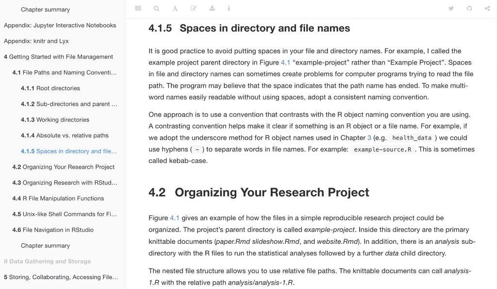